# FIM Components Summary

Manuel Alcalá Kovalski

10/16/2020

## Components

Our quarterly fiscal impact measure is:

$$FIM_{t} = FIM^{Fed}_{t} + FIM^{S \&L}_{t} + FIM^{Taxes \ \& \ Transfers}$$

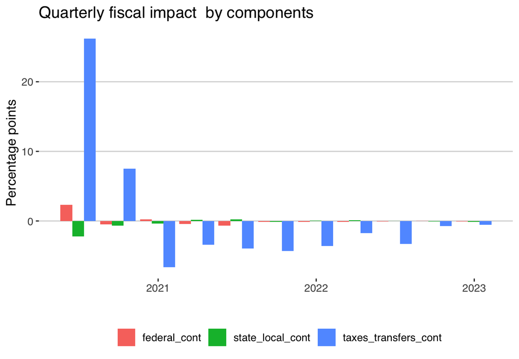

### Federal purchases

The contribution of federal purchases is the sum of the contributions of federal spending, consumption grants, and investment grants to GDP.

$$FIM^{Fed,\ Purchases}_{t} = FIM^{Fed,\ Spending}_{t} + FIM^{Fed, \ Consumption\ Grants}_{t} + FIM^{Fed, \ Investment\ Grants}_{t}$$

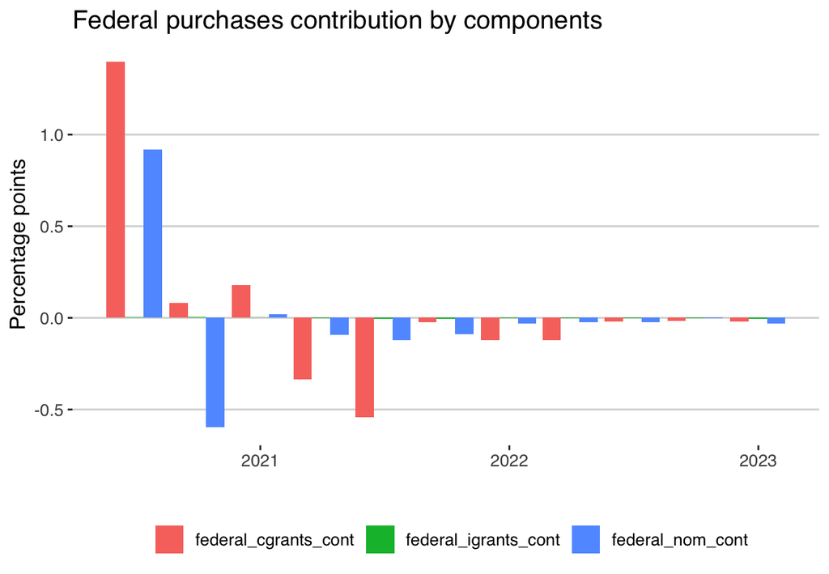

### State purchases

Similarily, the contribution of state & local purchases is the sum of the contributions of State & Local spending minus consumption grants, and investment grants to GDP. That is,

$$FIM^{S\&L,\ Purchases}_{t} = FIM^{S\&L,\ Spending}_{t} - FIM^{Fed,\ Consumption\ Grants}_{t} - FIM^{Fed,\ Investment\ Grants}_{t}$$

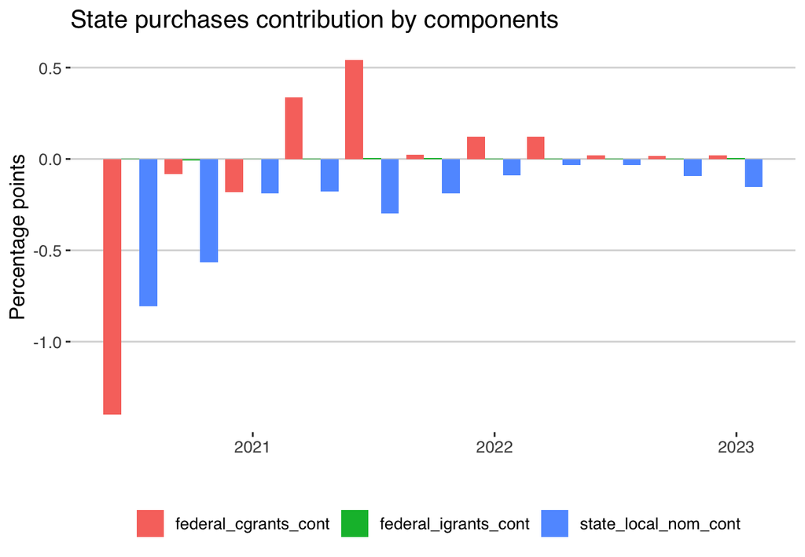

The pieces used to calculate these contributions were nominal federal and S&L spending, federal consumption grants, and investment grants. Federal consumption grants consist of federal consumption grants to state net of Medicaid grants.

[figure not shown]

To understand the level of our federal cgrants we must know the levels for gross consumption grants, medicaid grants, health and hospital grants. Because of COVID legislation, we also need to know our add factor for net consumption grants.

[figure not shown]

### Taxes, transfers and subsidies

$$FIM^{Taxes\ \& \ Transfers} = FIM^{Taxes\ \&\ Transfers} + FIM^{Subsidies}$$

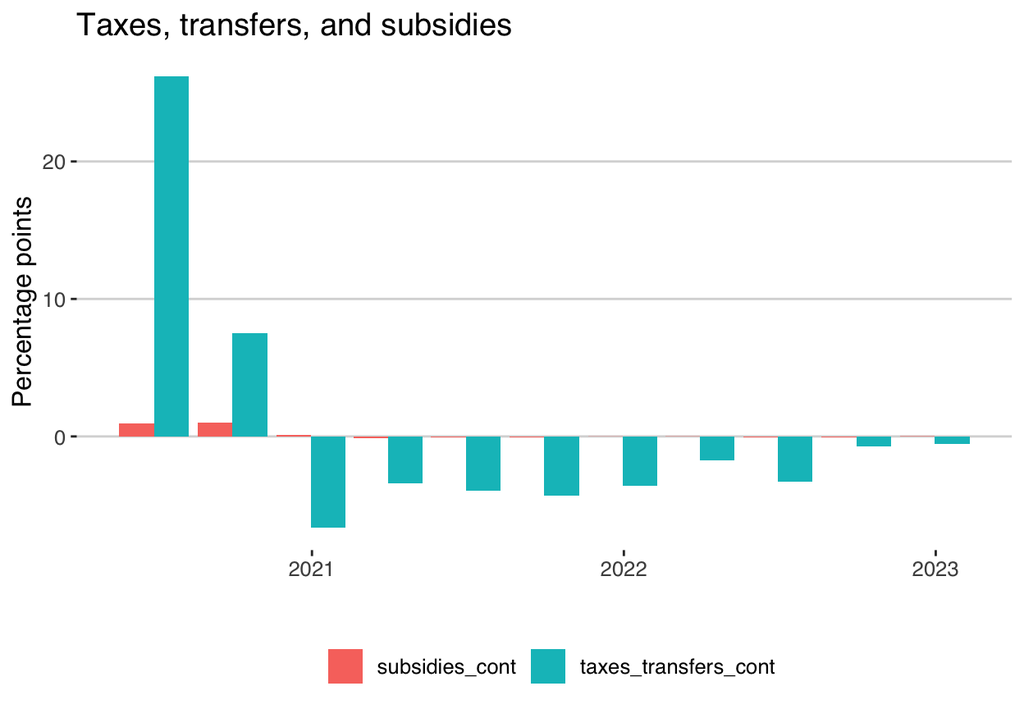

### Taxes, transfers, subsidies by level of government

#### Government Taxes

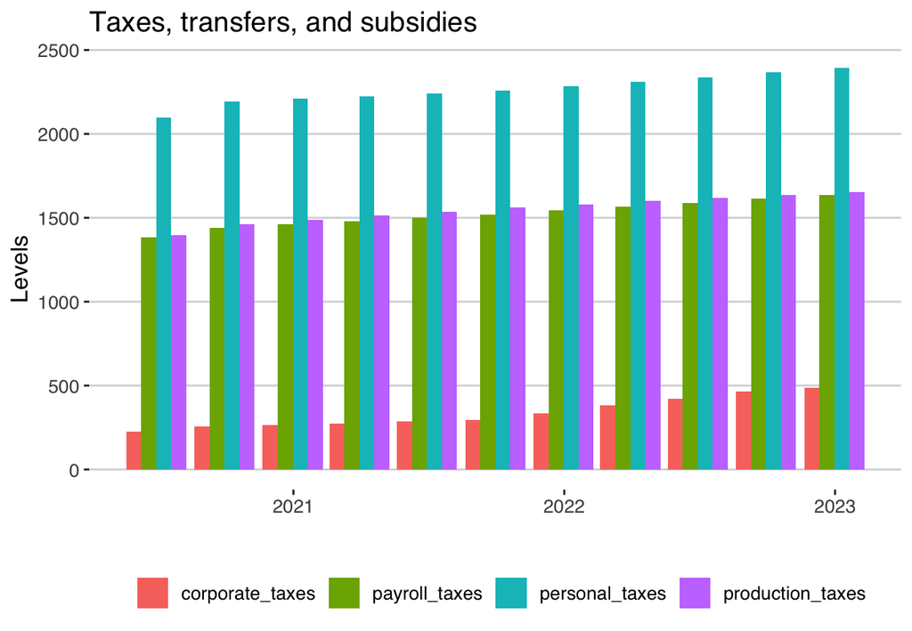

### Federal Taxes

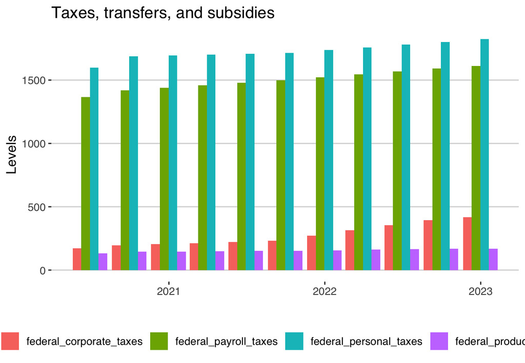

### State & Local Taxes

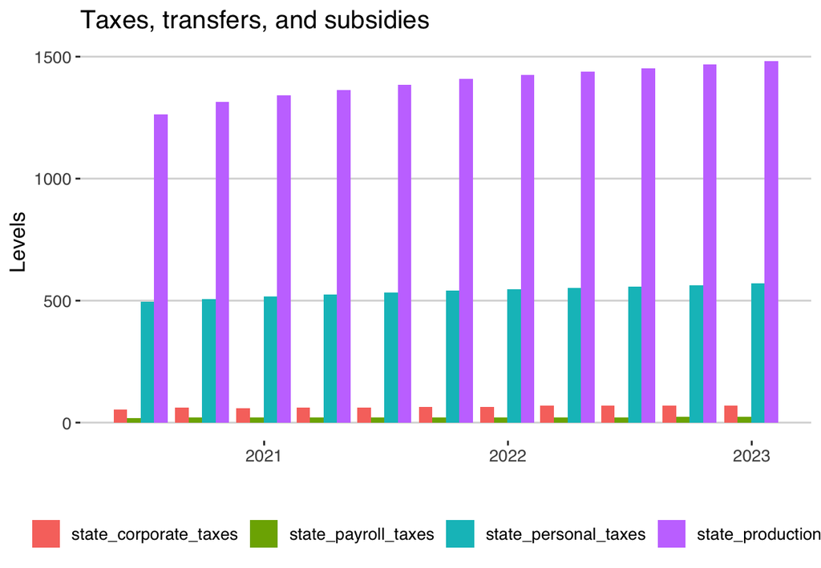

### Government Transfers

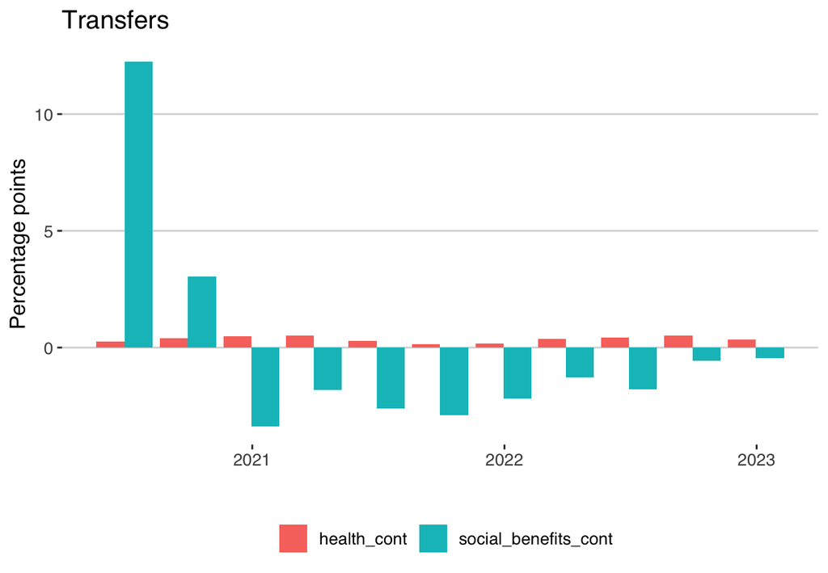

Social benefit payments to persons includes social security benefits, medical benefits, veterans benefits, and unemployment insurance benefits.

During our projection period, we include add factors to account for COVID-19 legislation.

[figure not shown]

### Subsidies

[figure not shown]